# Online Retail Analysis

### Customer Returns

```python
# Check the number of return records with missing CustomerID before starting
# customer-level return analysis.
returns_df['CustomerID'].isna().sum(), returns_df['CustomerID'].count()
```

```
(np.int64(162), np.int64(8506))
```

```python
# Remove return records without CustomerID, since they cannot be attributed to
# individual customers and therefore cannot be used in customer-level return analysis.
customer_returns_df = returns_df.dropna(subset=['CustomerID']).copy()
```

```python
# Identify the customers with the highest number of return transactions.
# We use the number of unique invoices rather than individual returned product
# lines, since a single return transaction may contain multiple products.
customer_returns_transactions=customer_returns_df.groupby('CustomerID')['InvoiceNo'].nunique().sort_values(ascending=False).head()

customer_returns_transactions

# The five customers with the highest number of return transactions are selected
# for a closer examination of how their return activity develops over time.
```

```
CustomerID
17841.0    45
14911.0    44
14606.0    35
15311.0    27
13089.0    21
Name: InvoiceNo, dtype: int64
```

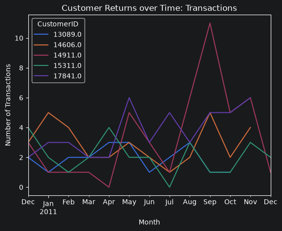

```python
# Store the CustomerIDs of the leading customers for subsequent filtering
# and visualization.
customer_ids=customer_returns_transactions.index.to_list()

# Reset the index before applying groupby() and resample() to ensure consistent
# indexing after the previous filtering operations.
customer_returns_df=customer_returns_df.reset_index(drop=True)

# Aggregate return activity by customer and month.
# InvoiceNo counts the number of unique return transactions, while Quantity
# represents the total number of returned units during each month.
customer_returns_dynamic=customer_returns_df.groupby('CustomerID').resample('ME', on='InvoiceDate').agg({'InvoiceNo': 'nunique', 'Quantity': 'sum'}).reset_index()

# Convert the monthly timestamps into monthly periods to make the time axis
# easier to read.
customer_returns_dynamic['InvoiceDate']=customer_returns_dynamic['InvoiceDate'].dt.to_period('M')

# Visualize the monthly return frequency of the five customers with the
# highest overall number of return transactions.
ax = customer_returns_dynamic[customer_returns_dynamic['CustomerID'].isin(customer_ids)].pivot(index='InvoiceDate', columns='CustomerID', values='InvoiceNo').plot()

ax.set_xlabel('Month')
ax.set_ylabel('Number of Transactions')
ax.set_title('Customer Returns over Time: Transactions')

# The leading customers by number of return transactions show relatively
# consistent return activity throughout the analyzed period.
#
# Although Customer 14911 records a noticeable increase in September 2011,
# the difference amounts to only a few additional return transactions and
# does not represent a substantial anomaly.
#
# Overall, the leading positions appear to result from recurring return
# activity across multiple months rather than isolated extreme events.
```

```python
# Identify the customers responsible for the largest total quantities of returned
# products. The top eight customers are initially selected to preserve enough
# observations after several exceptional cases are excluded from the subsequent
# time-based comparison.
customer_returns_quantity=returns_df.groupby('CustomerID')['Quantity'].sum().sort_values(ascending=False).head(8)

# Customers 16446, 12346 and 15838 are excluded from the following comparison
# because their total returned quantities are dominated by single exceptionally
# large return transactions. These cases are examined separately below.
customer_ids=customer_returns_quantity.index.to_list()
customer_ids.remove(16446.0)
customer_ids.remove(12346.0)
customer_ids.remove(15838.0)

customer_returns_quantity
```

```
CustomerID
16446.0    80995
12346.0    74215
15838.0     9360
15749.0     9014
16029.0     6420
12931.0     4427
14607.0     3768
14911.0     3331
Name: Quantity, dtype: int64
```

```python
# Inspect the three exceptional customers whose total returned quantities are
# dominated by unusually large individual return transactions.
returns_df.loc[returns_df['CustomerID'].isin([16446.0, 12346.0, 15838.0])]

# All three exceptional customers are associated with extremely concentrated
# return events:
#
# - Customer 16446 returned 80,995 units of "PAPER CRAFT, LITTLE BIRDIE".
# - Customer 12346 returned 74,215 units of "MEDIUM CERAMIC TOP STORAGE JAR".
# - Customer 15838 returned 9,360 units of "ROTATING SILVER ANGELS T-LIGHT HLDR".
#
# The first case was already linked to the previously identified exceptional
# purchase of 80,995 units. The other two products had also appeared among the
# leaders by total returned quantity in the earlier product-level analysis.
# This additional customer-level investigation reveals that their unusually
# high return volumes are similarly concentrated in single return transactions.
#
# Therefore, these cases should be interpreted as isolated high-volume return
# events rather than persistent return behavior. However, the dataset does not
# contain information about the reasons for these returns, so their underlying
# causes cannot be determined.
```

|  | InvoiceNo | StockCode | Description | Quantity | InvoiceDate | UnitPrice | CustomerID | Country |
| --- | --- | --- | --- | --- | --- | --- | --- | --- |
| 32 | C536757 | 84347 | ROTATING SILVER ANGELS T-LIGHT HLDR | 9360 | 2010-12-02 14:23:00 | 0.03 | 15838.0 | United Kingdom |
| 985 | C541433 | 23166 | MEDIUM CERAMIC TOP STORAGE JAR | 74215 | 2011-01-18 10:17:00 | 1.04 | 12346.0 | United Kingdom |
| 8662 | C581484 | 23843 | PAPER CRAFT , LITTLE BIRDIE | 80995 | 2011-12-09 09:27:00 | 2.08 | 16446.0 | United Kingdom |

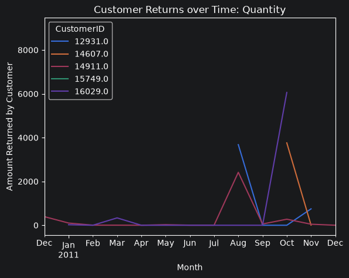

```python
# Examine the monthly returned quantities of the next five leading customers
# after excluding the three exceptional single-transaction cases.
ax = customer_returns_dynamic[customer_returns_dynamic['CustomerID'].isin(customer_ids)].pivot(index='InvoiceDate', columns='CustomerID', values='Quantity').plot()

ax.set_xlabel('Month')
ax.set_ylabel('Amount Returned by Customer')
ax.set_title('Customer Returns over Time: Quantity')

# Even after excluding the three extreme single-transaction cases, returned
# quantities among the remaining leading customers are often concentrated in
# individual months rather than distributed consistently throughout the year.
#
# This suggests that temporal concentration is not unique to the most extreme
# return-volume outliers. Similar patterns are also present among customers with
# considerably smaller overall returned quantities.
#
# A comparable pattern can also be observed at the product level. Therefore,
# unusually concentrated return activity should not automatically be interpreted
# as evidence of a specific problem with either a customer or a product.
# Since the dataset provides no information about return reasons, the causes
# behind these concentrated return events cannot be reliably determined.
```

Customer return activity is relatively stable when measured by the **number of return transactions**. Customers **17841 and 14911** stand out as the most consistent returners, recording the highest overall numbers of return transactions while remaining active across much of the analyzed period. Even the temporary increase observed for Customer 14911 in September represents only a small absolute difference in transaction count and does not constitute a substantial anomaly.

A different pattern emerges when returns are measured by the **total quantity of products returned**. Several customers record exceptionally large totals that are heavily concentrated in individual return transactions.

**Further investigation revealed that three of the products previously identified among the leaders by returned quantity are dominated by exceptionally large single return events: Customer 16446 returned 80,995 units of "PAPER CRAFT, LITTLE BIRDIE", Customer 12346 returned 74,215 units of "MEDIUM CERAMIC TOP STORAGE JAR", and Customer 15838 returned 9,360 units of "ROTATING SILVER ANGELS T-LIGHT HLDR". The latter two products had already appeared among the leading returned products in the earlier product-level analysis, but their concentration within individual return transactions had not yet been identified.**

However, concentrated return activity is not limited to these extreme cases. Even after excluding them, several leading customers show large portions of their returned quantities concentrated in individual months. A similar pattern is visible at the product level.

Therefore, unusually concentrated returns should not automatically be interpreted as evidence of problematic customer or product behavior. Since the dataset contains no information about **return reasons**, the underlying causes of these events cannot be reliably determined.

## Returns Analysis Summary

Returns represent a **relatively small and structurally distinct part of the store's overall activity**. Their frequency generally follows overall transaction volume, while their financial impact is less predictable and depends more strongly on the quantities and prices involved in individual return events.

Geographically, returns remain **strongly concentrated in the United Kingdom**, largely reflecting the store's overall market structure. International returns tend to involve somewhat larger quantities, while returned product prices remain broadly similar across markets.

At the product level, **"REGENCY CAKESTAND 3 TIER" stands out as the most consistently returned product**, while several other return-volume leaders are driven by large quantities concentrated in isolated periods. Customer-level analysis reveals a similar distinction: **Customers 17841 and 14911 show the most persistent return activity by transaction frequency**, whereas the largest returned quantities are often associated with individual high-volume events.

Several extreme cases were traced to single transactions, most notably the **80,995-unit return of "PAPER CRAFT, LITTLE BIRDIE"**, which connects directly to the exceptional purchase identified earlier in the analysis. Similar concentration was subsequently identified for two other major return-volume outliers.

Overall, the analysis suggests that returns are **not a major systematic burden on the store's activity**, but their structure contains occasional extreme events capable of strongly affecting product-, customer- and revenue-level statistics. Since the dataset does not provide return reasons, the underlying causes of these events cannot be reliably determined.

# Final Conclusions

## Business Overview and Key Findings

The analysis presents the store as a **predominantly volume-driven retail business**. Changes in revenue are primarily associated with changes in the number of transactions rather than substantial shifts in typical transaction values. This is particularly visible during the final complete months of the dataset: from **September to November 2011, the store experienced sustained revenue growth**, culminating in November — the final full month of observations — with more than **£1.5 million in revenue from 2,751 unique orders**.

Although December 2011 contains only **nine days of observations** and therefore cannot be directly compared with complete months, its performance still indicates strong sales activity: during this short period, the store had already generated more revenue than in the complete months of February and April.

At the same time, the store demonstrates clear **seasonal behavior**. Toward the end of the year, Christmas- and holiday-related products become increasingly prominent among frequently purchased items. Consequently, part of the strong late-year performance may be associated with seasonal demand, meaning that the September–November growth should not automatically be interpreted as evidence of a permanent long-term growth trend. Nevertheless, within the available observation period, the store finishes the year with **substantially stronger commercial activity than during most earlier months**.

Geographically, the business is **strongly concentrated in its domestic UK market**. The United Kingdom accounts for **86.19% of total revenue and 90.61% of all transactions**. International trade therefore represents a considerably smaller part of the store's activity, although international transactions generally show a **higher-value structure** than domestic UK transactions.

Despite the relatively small role of international sales, the store maintains a **stable core of foreign markets**. Germany, France, EIRE and Belgium consistently appear among the leading countries by transaction frequency across different periods, while markets such as the Netherlands also make a particularly strong contribution to international revenue. Overall, the five largest foreign markets account for approximately **71.38% of international revenue and 69.94% of international transactions**, despite the store reaching **35 international markets**. This indicates that the international side of the business is geographically broad but commercially concentrated around a relatively small and persistent group of important trading relationships.

The product analysis reveals a **diversified structure of product success** rather than dependence on a single universally dominant group of items. Product price shows almost no linear relationship with total quantity sold, with a correlation of approximately **-0.10**, providing no evidence that more expensive products are systematically purchased in smaller quantities.

At the same time, no single metric is sufficient to define the store's "best" product. Quantity sold, transaction frequency and total revenue capture different aspects of product performance, and different products lead under different measures. Several products nevertheless demonstrate consistently strong results across multiple dimensions and periods, particularly **WHITE HANGING HEART T-LIGHT HOLDER, JUMBO BAG RED RETROSPOT, and ASSORTED COLOUR BIRD ORNAMENT**. **REGENCY CAKESTAND 3 TIER** also stands out through its combination of high revenue, frequent purchases and temporal stability. Overall, the store does not appear to depend on a single flagship product, but instead benefits from a **broader group of repeatedly successful products**.

A similar structure can be observed among customers. The store has a **relatively small but persistent group of highly active and high-value buyers**, although customer importance takes different forms. Some customers stand out primarily through transaction frequency, others through total revenue, while the strongest combine both characteristics. Their activity is also relatively stable over time, suggesting the presence of a recurring core customer base rather than a constantly changing group of major buyers.

Several products repeatedly appear in purchases made by these key customers, most notably **JUMBO BAG RED RETROSPOT, WHITE HANGING HEART T-LIGHT HOLDER, and PACK OF 72 RETROSPOT CAKE CASES**. These products also performed strongly in the independent product analysis, providing additional evidence of sustained demand. Geographically, the key-customer structure closely follows the overall business: **13 of the 17 identified key customers are located in the United Kingdom**.

No clear evidence of systematic preferential pricing for these key customers was identified in the available transaction data. Their importance therefore appears to be primarily associated with their **purchasing frequency, order volumes and financial contribution**, rather than an observable pattern of consistently reduced prices.

Finally, returns do not appear to represent a **major systematic threat to the store's overall activity**. Their frequency generally follows overall transaction volume, indicating that return activity tends to increase as general sales activity increases rather than behaving as an independent negative trend. Their overall scale and financial impact remain relatively limited compared with regular sales.

Overall, the store appears to have a **relatively stable and diversified commercial structure**. Its revenue is primarily supported by transaction volume, its domestic UK market provides a strong core of activity, and both its product portfolio and customer base contain persistent high-performing groups rather than depending entirely on individual products or buyers. International activity remains secondary but is supported by stable foreign markets, while returns remain limited in overall scale.

The strongest growth observed toward the end of the analyzed period provides **positive evidence regarding the store's sales performance**, although the presence of seasonal demand and the limited observation period prevent this from being interpreted as definitive evidence of long-term growth. Within the scope of the available data, however, there are **no clear signs of broad commercial deterioration**, while several indicators point toward a stable business experiencing particularly strong activity toward the end of 2011.

## Limitations

Several limitations of the dataset should be considered when interpreting the results of this analysis.

- **Limited observation period:** The dataset covers approximately one year of transactions. This is sufficient to identify short-term trends and seasonal patterns, but it does not allow us to determine whether the observed late-year revenue growth represents a persistent long-term trend or a temporary development.
- **Incomplete December 2011 data:** The dataset ends on December 9, meaning that December contains only nine days of observations. Although these records provide some indication of continued strong sales activity, December cannot be directly compared with complete months.
- **Extreme and potentially erroneous transactions:** Several exceptionally large purchases and returns strongly affect certain product-, customer- and revenue-level statistics. The clearest examples include the 80,995-unit purchase and subsequent return of **PAPER CRAFT, LITTLE BIRDIE**, as well as similarly concentrated activity involving **MEDIUM CERAMIC TOP STORAGE JAR**. The dataset provides no behavioral or operational context explaining these transactions, making it impossible to determine whether they represent genuine bulk orders, human errors, system errors, or another type of event. Such observations can substantially distort rankings, distributions and visualizations if interpreted without additional investigation.
- **Unknown return reasons:** Although return transactions can be identified and analyzed, the dataset does not explain why products were returned. Consequently, unusual return patterns cannot reliably be attributed to product quality, ordering mistakes, customer behavior, logistical problems or other causes.
- **Limited geographic context:** International transactions generally have a higher-value structure than domestic UK transactions, but the dataset does not explain why. Potential factors such as shipping costs, taxes, duties or other operational differences cannot be reliably connected to individual orders. Operational records such as delivery-related charges and manual adjustments exist in the dataset, but their exact relationship with regular transactions is not sufficiently documented to establish such explanations.
- **Limited customer information:** Customers are represented primarily by anonymous identifiers and transaction histories. There is no information about customer characteristics, business types or motivations. As a result, purchasing patterns can be identified, but the underlying reasons for them — including whether particular customers represent wholesalers, businesses or individual consumers — cannot be established reliably.
- **Unclear pricing and discount structure:** The dataset does not provide explicit information about standard product prices, customer-specific discounts or pricing agreements. Therefore, differences in observed unit prices cannot always be interpreted as evidence of discounts or preferential pricing.
- **Ambiguous non-product and adjustment records:** Several special `StockCode` values represent transactions that do not behave like ordinary product sales, including operational charges, manual entries and other non-revenue-related records. The dataset also contains unusual entries such as records with negative prices. While these observations can be identified and separated from regular product transactions, their exact accounting or operational meaning is not always documented. Consequently, some of these records cannot be interpreted with certainty and must be handled cautiously depending on the purpose of the analysis.